# real data analysis

Cherlane Lin

June 20, 2021

## File Introduction

This is the R file including all the content related to real data analysis. Please run all of it from the beginning to the end by order The main content of this file includes:

0. Installing required packages
1. Data importing and dataset merging
2. Data exploration (fig 1,2,3)
3. Smooth FPCA on B-spline Non-parametric Regression (fig 4)
4. Clustering
5. Final Result Visualization (fig 5, 6, 7, table 1)

PLEASE USING *WINDOWS* SYSTEM to execute the code so as to reproduce the figures and tables in the paper! Ubuntu and OS system have different setting on seed setting, so the execution result would be slightly different on these two system. Moreover, our key algorithm FunFEM would diverge or fail on some seed, so we strongly suggest to use WINDOWS system to execute the code.

Please install the ‘fiftystater’ through the fiftystater_1.0.1.tar in the file list, which would be used in the map plotting of figure 5

In addition, FunFEM would try multiple variance and covariance matrix form to get the best result. In some forms, the result would be diverge and you may see some warning or message like

"Error in svd(ginv(t(G) %*% G %*% W) %*% (t(G) %*% Ttilde %*% t(Ttilde) %*% : infinite or missing values in ‘x’" “Error in svd(X) : infinite or missing values in ‘x’”

This is not a real error and the code would keep running.

## Coding Part for Real Data Analysis

### 0. Installing required packages

ipak is a function for checking the existance of the required package. If the packages do not exist in the system, then installation of the packages would start

Since the fiftystater is no longer at Cran, so please download the fiftystater tar from Git and install through tar separately

```r
ipak <- function(pkg){
  new.pkg <- pkg[!(pkg %in% installed.packages()[, "Package"])]
  if (length(new.pkg))
    install.packages(new.pkg, dependencies = TRUE)
  sapply(pkg, require, character.only = TRUE)
}

# add new packages here
packages <- c("ggplot2", "dplyr", "tidyverse", "tidyr", "geosphere",
              "ggridges","scales","geofacet","lubridate","fda","fda.usc","RColorBrewer",
              "ggrepel","DT","forecast","maps","usmap","clue",
              "ggthemes","gridExtra","factoextra", "fiftystater",
              "NbClust","funFEM","mapproj")
ipak(packages)
```

```
##      ggplot2        dplyr    tidyverse        tidyr    geosphere     ggridges
##         TRUE         TRUE         TRUE         TRUE         TRUE         TRUE
##       scales     geofacet    lubridate          fda      fda.usc RColorBrewer
##         TRUE         TRUE         TRUE         TRUE         TRUE         TRUE
##      ggrepel           DT     forecast         maps        usmap         clue
##         TRUE         TRUE         TRUE         TRUE         TRUE         TRUE
##     ggthemes    gridExtra   factoextra  fiftystater      NbClust       funFEM
##         TRUE         TRUE         TRUE         TRUE         TRUE         TRUE
##      mapproj
##         TRUE
```

```r
## The package fiftystater is for the U.S map visualization, and it may be unavailable on CRAN
## So its achieved file is attached in the Github repository with the path
```

### 1. Dataset importing and processing

```r
## Dataset Importing
#Location Dataset
loc <- read.csv("locations.csv",header = T, stringsAsFactors = F)
loc$city_index <- as.numeric(rownames(loc))

# Historical Weather Dataset
hist <- read.csv("histWeather.csv",header = T, stringsAsFactors = F)
hist$Date = as.Date(hist$Date,format = "%Y-%m-%d")
hist <- unique(hist)
index=which.max(hist$Max_TemperatureF)
hist=hist[-c(index),]

# Forecast Weather Dataset
forecast <- read.table("forecast.dat", header=F, stringsAsFactors = F)
colnames(forecast) = c("city_index","forecast_date","forecast_value","forecast_goal",
                       "forecast_made_on")
forecast <- forecast %>%
  mutate(
    forecast_date = as.Date(forecast_date,format = "%Y-%m-%d"),
    forecast_made_on = as.Date(forecast_made_on,format = "%Y-%m-%d"),
    # double check the meaning of "M" in forecast_value
    forecast_value = as.numeric(forecast_value)
  )

## 2. Joining the dataset
# merge MinTemp with MaxTemp
fore_min_max <- full_join(
  x = forecast %>% filter(forecast_goal=="MinTemp") %>%  dplyr::select(-forecast_goal) %>% na.omit() %>% unique(),
  y = forecast %>% filter(forecast_goal=="MaxTemp") %>%  dplyr::select(-forecast_goal) %>% na.omit() %>% unique(),
  by = c("city_index","forecast_date","forecast_made_on"),
  suffix = c("_min", "_max")) %>% unique()

# merge MinTemp, MaxTemp, ProbPrecip and location to get fore_full_loc data
fore_full_loc <-
  # merge fore_min_max with ProbPrecip
  full_join(
    x = fore_min_max,
    y = forecast %>% filter(forecast_goal=="ProbPrecip") %>% dplyr::select(-forecast_goal),
    by = c("city_index", "forecast_date", "forecast_made_on")
  ) %>% unique() %>%
  dplyr::rename(  forecast_MinTemp = forecast_value_min,
                  forecast_MaxTemp = forecast_value_max,
                  forecast_ProbPre = forecast_value) %>%
  # merge fore_min_max_precip with location data
  left_join(y = loc, by = "city_index")

# master data with all infomation
df <- left_join( x = fore_full_loc, y = hist,
                 by = c("forecast_date"= "Date", "AirPtCd" = "AirPtCd"))

# Daily Forecast Final Dataset
df.min.max <- df %>% dplyr::group_by(city_index,forecast_date,forecast_made_on,city,state,AirPtCd) %>%
  dplyr::summarise(forecast_MinTemp = mean(forecast_MinTemp, na.rm=T),
                   Min_TemperatureF = mean(Min_TemperatureF, na.rm=T),
                   Mean_TemperatureF = mean(Mean_TemperatureF, na.rm=T),
                   forecast_MaxTemp = mean(forecast_MaxTemp, na.rm=T),
                   Max_TemperatureF = mean(Max_TemperatureF, na.rm=T)
  ) %>% ungroup() %>%
  mutate(dayDiff = forecast_date - forecast_made_on,
         diffMin = forecast_MinTemp - Min_TemperatureF,
         diffMax = forecast_MaxTemp - Max_TemperatureF,
         year = lubridate::year(forecast_date),
         month = month(forecast_date),
         week = week(forecast_date),
         day = wday(forecast_date,label = T))

df.all <- left_join( x = df.min.max, y = hist %>% dplyr::select(-`Min_TemperatureF`,
                                                         Mean_TemperatureF,
                                                         Max_TemperatureF),
                     by = c("forecast_date"= "Date", "AirPtCd" = "AirPtCd"))

## We load the final dataset to a RData for further convenience
save(df.all, file = "df.min.max.RData")
```

#### data processing: summary and filing missing data

```r
load("df.min.max.RData")
df.all = df.all %>% mutate(city = factor(city), state = factor(state))
df.all$city_state = paste(df.all$city,df.all$state)
region <- read.csv("region-to-state.new.csv",header = T, stringsAsFactors = F)

df.full = df.all %>% left_join(region, by="state") # number of [diffMin == NA's] = 89911

# Remove outliers
outlier = df.full %>% filter(diffMin< -50 | diffMin> 50) # 22 outliers
df = df.full %>% filter(diffMin>= -50)%>% filter(diffMin <= 50) # 726714 = 816647-89911-22

# Replace [Events == ""] to Normal and change the format of some variables
df$Events=as.character(df$Events)
df$Events[df$Events==""]<-"Normal"
df$CloudCover = factor(df$CloudCover)
df$PrecipitationIn = as.numeric(df$PrecipitationIn)
df$season = 4
df[df$month<12 & df$month>8,]$season = 3
df[df$month<9 & df$month>5,]$season = 2
df[df$month<6 & df$month>2,]$season = 1
df$season = factor(df$season)
df$city_state = paste(df$city,df$state,sep = "_") ## Some states share some same city names (3 cities have this problem)

# Filtering the data related to the weather prediction with day difference  = 1
df$diffMin = abs(df$diffMin)
df$state = tolower(df$state)
state.mindiff.df.1=df%>%filter(dayDiff == 1) %>%
  dplyr::select(diffMin,forecast_date,state) %>%
  dplyr::group_by(forecast_date, state) %>%
  dplyr::summarise(avg=mean(diffMin,na.rm=T))

# Filling the missing value using weekly average for every state
try.1=state.mindiff.df.1 %>% spread(state, avg, fill=NA)

try.1$week=week(try.1$forecast_date)
try.1$year=lubridate::year(try.1$forecast_date)
try_new.1 <- try.1
try_new.1$forecast_date <- NULL

week.mean.err0.1 <- try_new.1 %>% dplyr::group_by(year,week) %>%
  dplyr::summarise_all(dplyr::funs(mean(.,na.rm = T)))

for (row in 1: nrow(try.1)) {
  for (col in 1: ncol(try.1)) {
    if(is.na(try.1[row,col])) {
      week=as.numeric(try.1[row,"week"])
      year=as.numeric(try.1[row,"year"])
      try.1[row,col] = as.numeric(week.mean.err0.1[week.mean.err0.1$week == week & week.mean.err0.1$year == year,col+1])
    }
  }
}
sum(is.na(try.1)) # summation  = 0, no missing value now
```

```
## [1] 0
```

```r
mindiff.state.1 = try.1[,-which(names(try.1) %in% c("forecast_date","week","year"))]
names(mindiff.state.1) = tolower(names(mindiff.state.1))
mindiff.date.1 = try.1$forecast_date
mindiff.state.mat.1 = matrix(unlist(mindiff.state.1),ncol = 50)

write.csv(mindiff.date.1,"mindiff_day1_nona.csv", row.names = F)
write.csv(mindiff.state.1,"mindiff_state1_nona.csv", row.names = F)
```

### 2. Data exploration (fig 1,2,3)

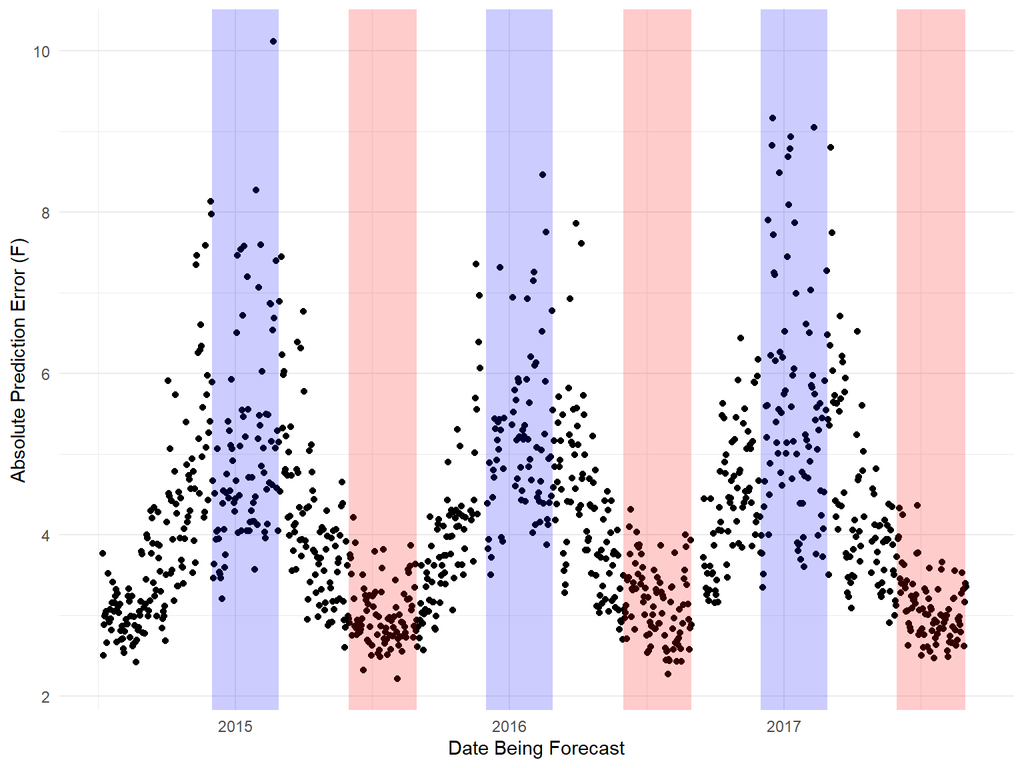

```r
## Fig 1:
ggplot(df.all %>% dplyr::group_by(forecast_date) %>% dplyr::summarise(avg=mean(abs(diffMin),na.rm=T)), aes(x=forecast_date, y=avg)) + geom_point() +
  theme_minimal() +
  annotate("rect", xmin = c(date("2014-12-01"),date("2015-12-01"),date("2016-12-01"),
                            date("2015-06-01"),date("2016-06-01"),date("2017-06-01")),
           xmax =c(date("2015-2-28"),date("2016-2-28"),date("2017-2-28"),
                   date("2015-08-31"), date("2016-08-31"), date("2017-08-31")),
           ymin = -Inf, ymax = Inf,
           alpha = 0.2, fill = c("blue","blue","blue","red","red","red")) +
  ylab("Absolute Prediction Error (F)")+
  xlab("Date Being Forecast")
```

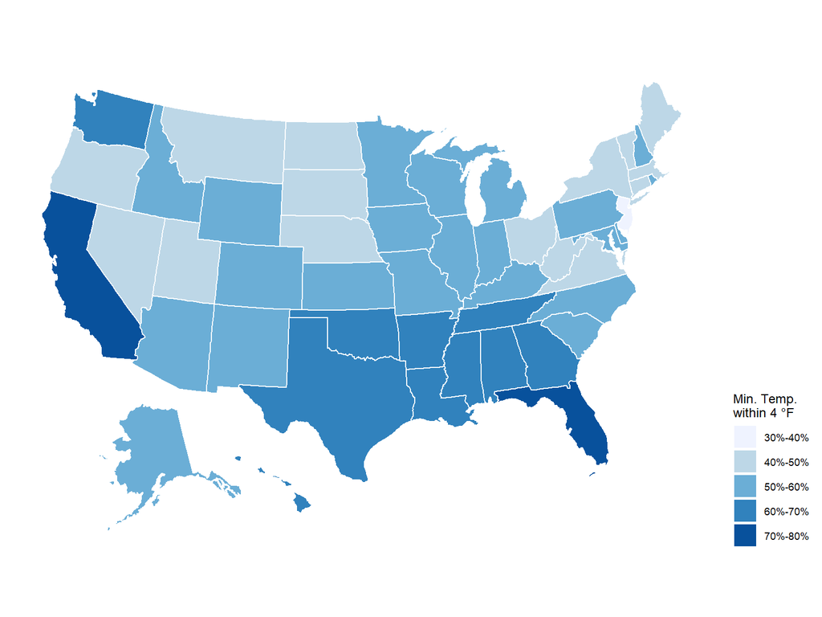

```r
## Fig 2: Prediction accuracy of minimum temperature for each U.S. state
df.all %>%
  dplyr::mutate(diff = ifelse(abs(forecast_MinTemp - Min_TemperatureF) < 4, 1, 0)) %>%
  dplyr::group_by(state) %>%
  dplyr::summarise(n = n(),
            per_diff = mean(diff, na.rm=T)
  ) %>%
  dplyr::mutate(per_diff_group = cut(per_diff,seq(0.3, 0.8, 0.1), include.lowest = TRUE, dig.lab = 2)) %>%
  usmap::plot_usmap(data = .,
             regions = "states",
             color = "white",
             values = "per_diff_group") +
  scale_fill_brewer(palette = "Blues",
                    na.translate = FALSE,
                    name = "Min. Temp.\nwithin 4 °F",
                    labels = c("30%-40%", "40%-50%", "50%-60%", "60%-70%", "70%-80%")
                    ) +
  theme(legend.position = "right")
```

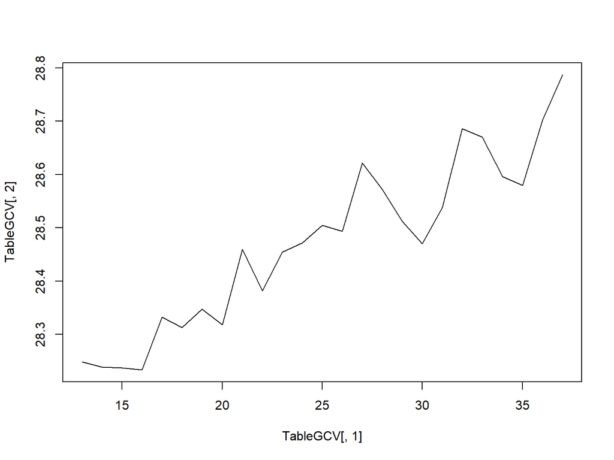

```r
## Fig 3: Fitting Longitudinal Data to Functional Data Using B-spline
# Generalized Cross-validation fo Knots Selection
TableGCV<-c()
for (j in 13:37) { # the interval width is select from every 4 months to every 1 month
  bks.cv = as.Date(quantile(unclass(mindiff.date.1), seq(0,1,length = j)), origin = "1970-01-01")
  err.basis.cv = create.bspline.basis(rangeval = c(min(mindiff.date.1),max(mindiff.date.1)), breaks = bks.cv, norder = 4)
  err.fit.cv = smooth.basis(argvals = mindiff.date.1, y = mindiff.state.mat.1, err.basis.cv)
  gcv.max <- max(err.fit.cv$gcv) # under each basis, record the maximum of GCV in 50 fitted curves for all states

  gcv.mu <- mean(err.fit.cv$gcv) # record the average GCV in 50 fitted curves for all states
  gcv.med <- median(err.fit.cv$gcv) # record the median of GCV in 50 fitted curves for all states
  TableGCV <- rbind(TableGCV,c(j,gcv.max,gcv.mu,gcv.med))
}

plot(TableGCV[,1], TableGCV[,2], type = "l")
```

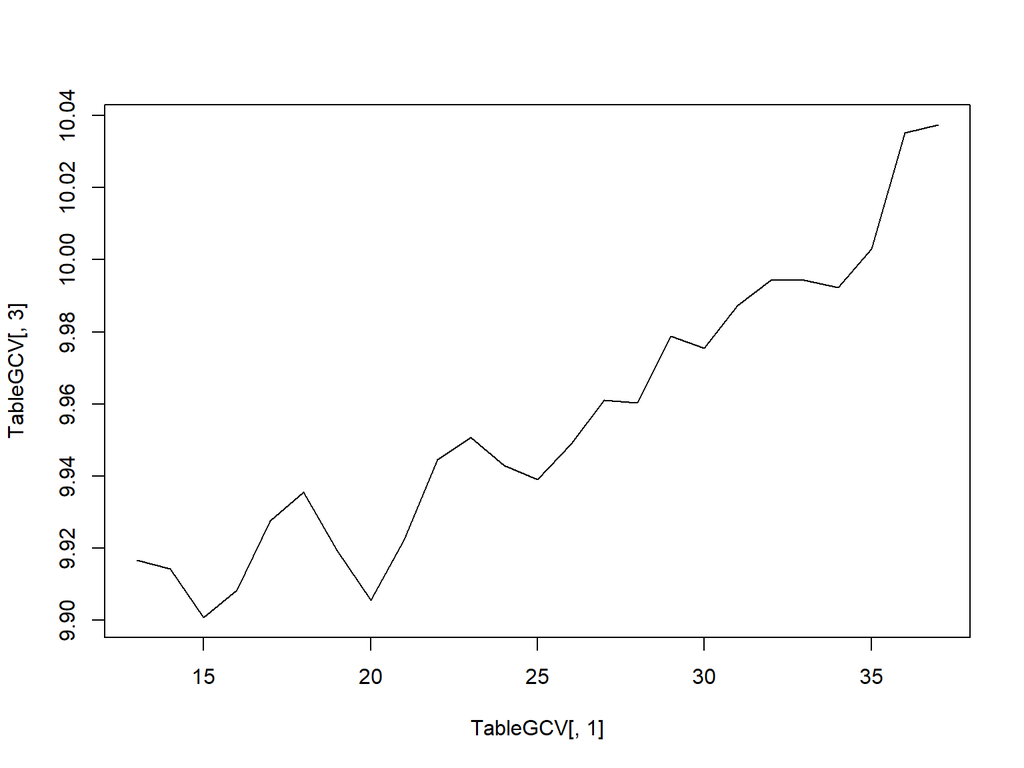

```r
plot(TableGCV[,1], TableGCV[,3], type = "l")
```

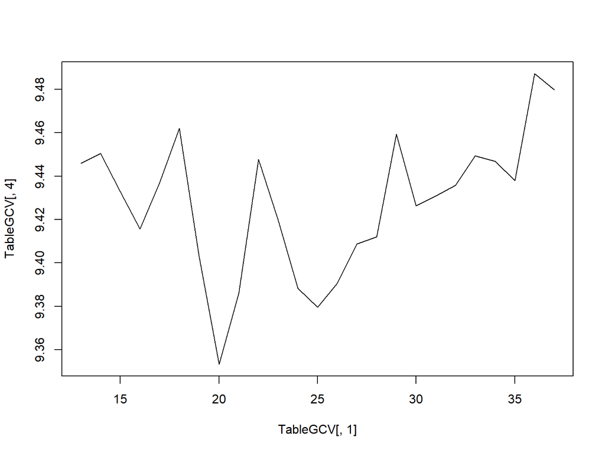

```r
plot(TableGCV[,1], TableGCV[,4], type = "l")
```

```r
bks.num.tab = TableGCV[order(TableGCV[,2]),]
bks.num.tab[1:5,]
```

```
##      [,1]     [,2]     [,3]     [,4]
## [1,]   16 28.23315 9.908327 9.415636
## [2,]   15 28.23720 9.900766 9.432928
## [3,]   14 28.23825 9.914232 9.450480
## [4,]   13 28.24812 9.916715 9.445888
## [5,]   18 28.31261 9.935447 9.462090
```

```r
bks.num.tab = TableGCV[order(TableGCV[,3]),]
bks.num.tab[1:5,]
```

```
##      [,1]     [,2]     [,3]     [,4]
## [1,]   15 28.23720 9.900766 9.432928
## [2,]   20 28.31805 9.905623 9.353277
## [3,]   16 28.23315 9.908327 9.415636
## [4,]   14 28.23825 9.914232 9.450480
## [5,]   13 28.24812 9.916715 9.445888
```

```r
bks.num.tab = TableGCV[order(TableGCV[,4]),]
bks.num.tab[1:5,]
```

```
##      [,1]     [,2]     [,3]     [,4]
## [1,]   20 28.31805 9.905623 9.353277
## [2,]   25 28.50489 9.938974 9.379550
## [3,]   21 28.45973 9.922330 9.386031
## [4,]   24 28.47185 9.942930 9.388320
## [5,]   26 28.49347 9.948833 9.390629
```

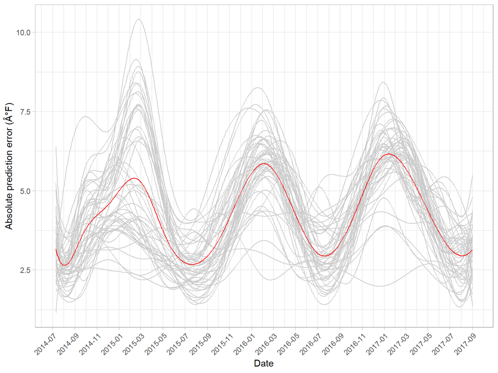

```r
## All three plots shows the first local minimum at around 15,
## so we finally select 15 seperating points (2 boundary and 13 interiors)
## producing 14 intervals with same data amount.

# Fitting and Visualize the Function Object
bks.1 = as.Date(quantile(unclass(mindiff.date.1), seq(0,1,length = 15)), origin = "1970-01-01")
err1.basis = create.bspline.basis(rangeval = c(min(mindiff.date.1),max(mindiff.date.1)), breaks = bks.1, norder = 4)
err1.fd<-smooth.basis(argvals = mindiff.date.1, y = mindiff.state.mat.1, err1.basis)$fd

####### Figure 3 #######################################################

## get the smoothed data of 50 stats in 1033 days
mindiff.smooth.err = eval.fd(mindiff.date.1, err1.fd)
colnames(mindiff.smooth.err) = colnames(mindiff.state.1)
write.csv(mindiff.smooth.err,"mindiff_state1_smooth.csv", row.names = F)

mindiff_day1_nona <- read_csv("mindiff_day1_nona.csv")
mindiff_state1_smooth <- read_csv("mindiff_state1_smooth.csv")

smooth_curve_df = bind_cols(mindiff_day1_nona, mindiff_state1_smooth) %>%
  rename(date = x)

curve_plot_df = smooth_curve_df %>%
  pivot_longer(
    cols = alabama:wyoming,
    names_to = "state",
    values_to = "temp"
  )

overall_mean_curve = smooth_curve_df %>%
  mutate(avg_temp = apply(smooth_curve_df[, 2:51], 1, mean)) %>%
  dplyr::select(date, avg_temp)

fig_3 = curve_plot_df %>%
  ggplot() +
  geom_line(aes(x = date, y = temp, group = state), col = "gray80") +
  geom_line(data = overall_mean_curve,
            aes(x = date, y = avg_temp), col = "red") +
  theme_light() +
  scale_x_date(date_breaks = "2 month", date_labels = "%Y-%m") +
  theme(axis.text.x = element_text(angle = 45, hjust = 1)) +
  ylab("Absolute prediction error (Â°F)") + xlab("Date")
fig_3
```

### 3. Clustering

#### 4. FPCA on smoothed data (fig 4)

```r
## 2. Using One-curve-out method to select the penalty size of the PCA Smoothing
# Step 1, determine the number of PC Functions through Non-smoothing PCA
# (at least 90% of Variation should be explained in the raw PC functions)
raw.fpca = pca.fd(err1.fd,nharm=5)
sum(raw.fpca$varprop) # Reach 90% Variation Excatly with 5 PC functions
```

```
## [1] 0.9232294
```

```r
# Step 2, Tuning Lambda
# Function for calculating the CV error for a given lambda
get.mcv.smoothfpca = function(lambda){
  range = c(as.numeric(min(mindiff.date.1)),as.numeric(max(mindiff.date.1)))
  bspFpcPen = fdPar(fdobj=err1.basis, Lfdobj=2, lambda = lambda)
  smooth.fpc.cv = c()
  for (i in 1:50){
    smooth.fpc.raw = err1.fd
    smooth.fpc.raw$coefs = err1.fd$coefs[,-i]
    smooth.fpc = pca.fd(smooth.fpc.raw,nharm=5,harmfdPar=bspFpcPen)
    smooth.fpc.coefs = as.matrix(smooth.fpc$harmonics$coefs) #17*5
    smooth.fpc.score = as.matrix(smooth.fpc$scores) #49*5

    smooth.fpc.xi.fd = err1.fd
    smooth.fpc.xi.fd$coefs = err1.fd$coefs[,i]
    smooth.fpc.xi = eval.fd(mindiff.date.1,smooth.fpc.xi.fd) - eval.fd(mindiff.date.1,smooth.fpc$meanfd) #1033*1
    smooth.fpc.basismat = eval.fd(mindiff.date.1,smooth.fpc$harmonics) #1033*5

    # estimate the SSE = y'y - y'X(X'X)X'y
    smooth.fpc.ri = t(smooth.fpc.xi)%*%smooth.fpc.xi - t(smooth.fpc.xi)%*%
      smooth.fpc.basismat%*%ginv(t(smooth.fpc.basismat)%*%smooth.fpc.basismat)%*%
      t(smooth.fpc.basismat)%*%smooth.fpc.xi
    smooth.fpc.cv = c(smooth.fpc.cv,smooth.fpc.ri)
  }
  return(sum(smooth.fpc.cv))
}

# Choosing lambda from (0:500)*5e2 and visualize the result, would take a long time
# table.lambda.mcv<-c()
# for (j in 1:501) {
#   smooth.fpc.cv  =  get.mcv.smoothfpca((j-1)*500)
#   table.lambda.mcv <- rbind(table.lambda.mcv,c(j,smooth.fpc.cv))
# }
#
# table.lambda.mcv = table.lambda.mcv[order(table.lambda.mcv[,1]),]
# plot(table.lambda.mcv[1:100,1]*5e2, table.lambda.mcv[1:100,2], type = "l",
#      main = "CV plot Lambda Selection",
#      xlab = "Lambda Value", ylab = "CV")
#
# table.lambda.mcv[,1] = table.lambda.mcv[,1]*500
# table.lambda.mcv = table.lambda.mcv[order(table.lambda.mcv[,2]),]
# table.lambda.mcv[1:5,]
# We can see that the local minimum of CV error is around the lambda = 18500


################################# Clustering ####################################
### Applying the Smooth FPCA on the Time series data with the tuning parameter lambda = 18500
### However, to visualize the FPC functions with more smoothness to show the main pattern, we use 2,000,000
### The Clustering result are exactly the same between lambda = 18500 and lambda = 2,000,000
range = c(as.numeric(min(mindiff.date.1)),as.numeric(max(mindiff.date.1)))
bspFpcPen = fdPar(fdobj=err1.basis, Lfdobj=2, lambda = 2e6)
## You can change to 18500
## The following clustering results are the same

###### Figure 4: PC Functions Explanation % #######
smooth.fpc = pca.fd(err1.fd,nharm=5,harmfdPar=bspFpcPen)
smooth.fpc$varprop ## PC1: 67.78%, PC2: 11.32%, PC3: 10.52%
```

```
## [1] 0.67771922 0.11324258 0.10524305 0.03597700 0.02218324
```

```r
sum(smooth.fpc$varprop)
```

```
## [1] 0.9543651
```

```r
###### Figure 4: PC Functions Visualization #######
op <- par(mfrow=c(2,3))
plot(smooth.fpc$harmonics[1],main = paste("Smoothed PC1 function"),
     ylab = "PC 1 Function Value", xlab = "date")
```

```
## [1] "done"
```

```r
plot(smooth.fpc$harmonics[2],main = paste("Smoothed PC2 function"),
     ylab = "PC 2 Function Value", xlab = "date")
```

```
## [1] "done"
```

```r
plot(smooth.fpc$harmonics[3],main = paste("Smoothed PC3 function"),
     ylab = "PC 3 Function Value", xlab = "date")
```

```
## [1] "done"
```

```r
plot(smooth.fpc$harmonics[4],main = paste("Smoothed PC4 function"),
     ylab = "PC 4 Function Value", xlab = "date")
```

```
## [1] "done"
```

```r
plot(smooth.fpc$harmonics[5],main = paste("Smoothed PC5 function"),
     ylab = "PC 5 Function Value", xlab = "date")
```

```
## [1] "done"
```

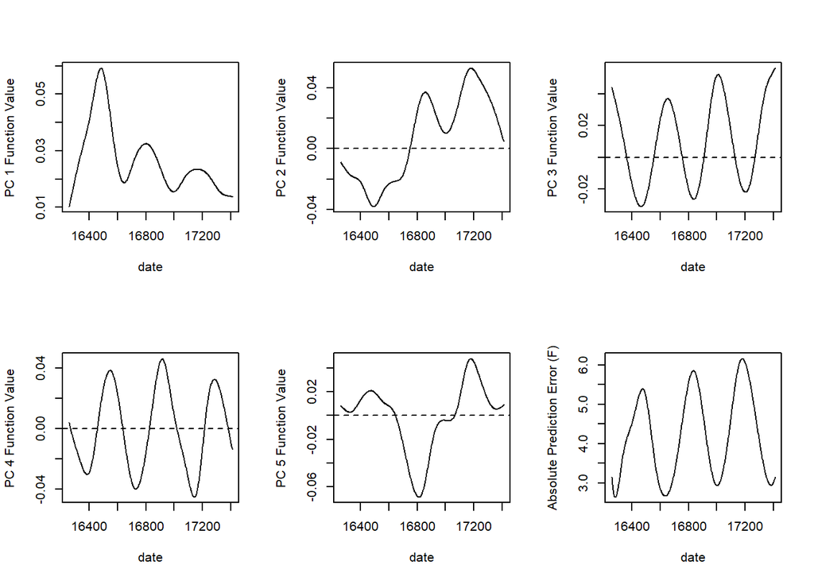

```
## [1] "done"
```

```r
plot(smooth.fpc$meanfd,main = "Mean Function",
     ylab = "Absolute Prediction Error (F)", xlab = "date")
```

#### 5. Clustering and Map Visualization (fig 5)

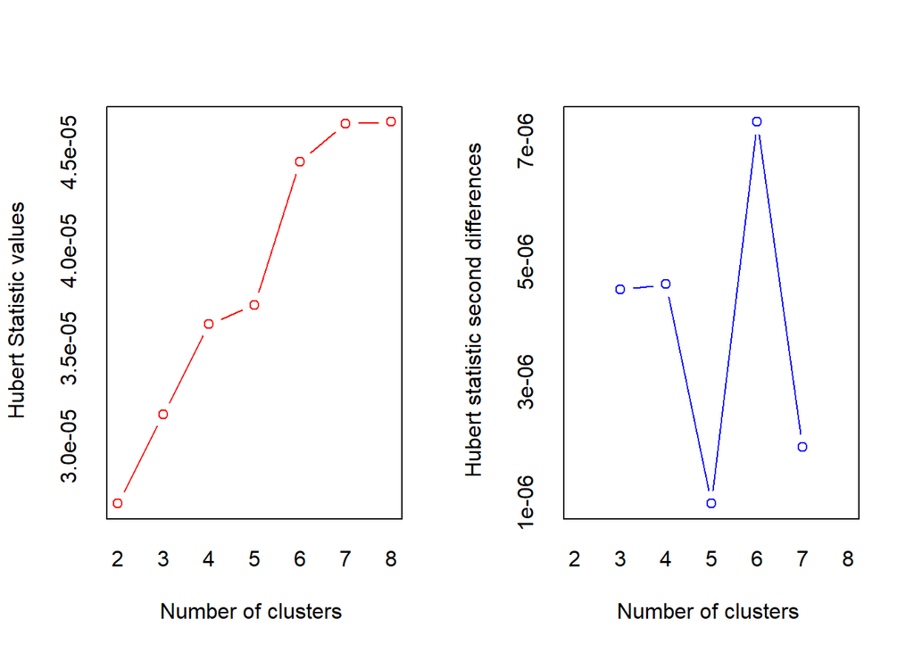

```
## *** : The Hubert index is a graphical method of determining the number of clusters.
##                 In the plot of Hubert index, we seek a significant knee that corresponds to a
##                 significant increase of the value of the measure i.e the significant peak in Hubert
##                 index second differences plot.
##
```

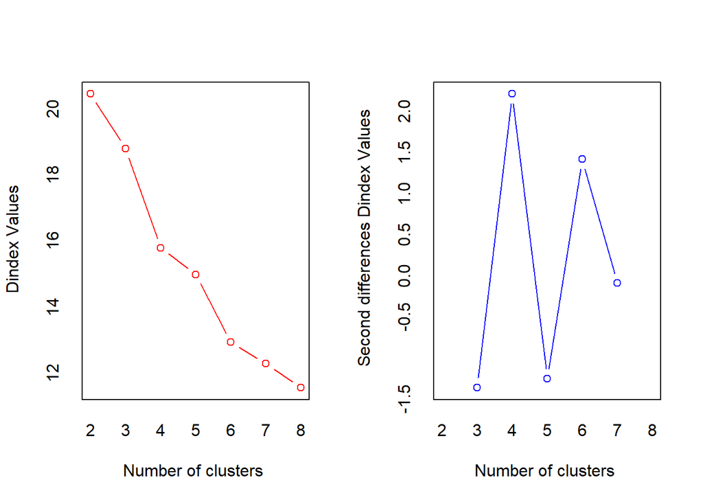

```
## *** : The D index is a graphical method of determining the number of clusters.
##                 In the plot of D index, we seek a significant knee (the significant peak in Dindex
##                 second differences plot) that corresponds to a significant increase of the value of
##                 the measure.
##
## * Among all indices:
## * 7 proposed 2 as the best number of clusters
## * 1 proposed 3 as the best number of clusters
## * 11 proposed 4 as the best number of clusters
## * 1 proposed 5 as the best number of clusters
## * 3 proposed 6 as the best number of clusters
## * 1 proposed 8 as the best number of clusters
##
##                    ***** Conclusion *****
##
## * According to the majority rule, the best number of clusters is  4
##
##
```

```r
############ Clustering Goal 1: Select Number of Clusters #############
####### Method 1: K-means on Smoothed FPC Scores
fpca.smooth <- data.frame(state = colnames(mindiff.state.1),
                          pc1 = smooth.fpc$scores[,1],
                          pc2 = smooth.fpc$scores[,2],
                          pc3 = smooth.fpc$scores[,3],
                          pc4 = smooth.fpc$scores[,4],
                          pc5 = smooth.fpc$scores[,5],
                          var.explain = sum(smooth.fpc$varprop),
                          daydiff = 1)

fpca.score = fpca.smooth%>%dplyr::select(pc1,pc2,pc3,pc4,pc5)
# Select number of cluster
set.seed(8888)
fpc.kmeans.num <- NbClust(fpca.score, distance = "euclidean",
                          min.nc=2, max.nc=8,
                          method = "kmeans",
                          index = "all")
```

```r
max(fpc.kmeans.num$Best.partition) ## suggest 4
```

```
## [1] 4
```

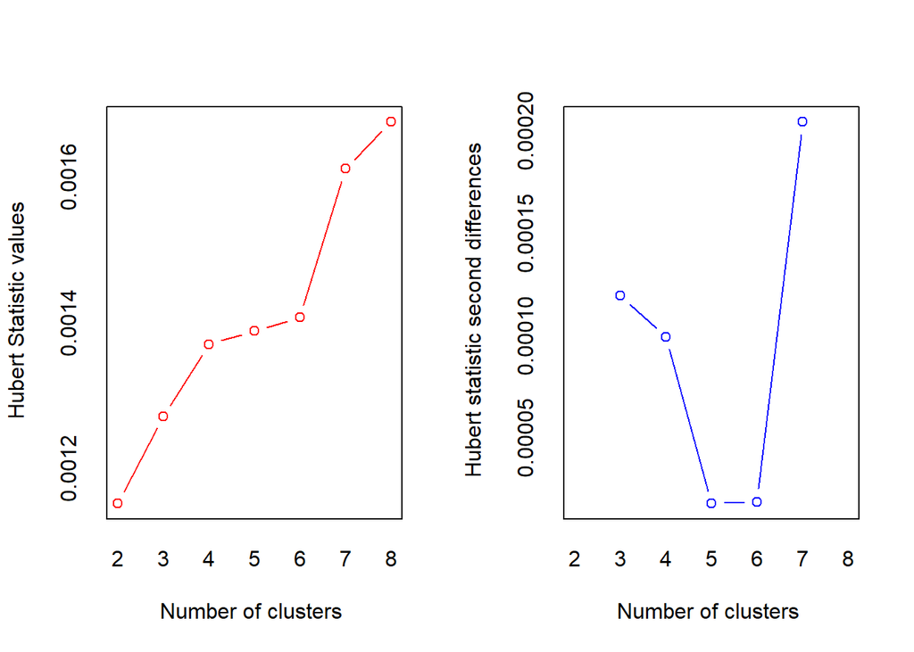

```
## *** : The Hubert index is a graphical method of determining the number of clusters.
##                 In the plot of Hubert index, we seek a significant knee that corresponds to a
##                 significant increase of the value of the measure i.e the significant peak in Hubert
##                 index second differences plot.
##
```

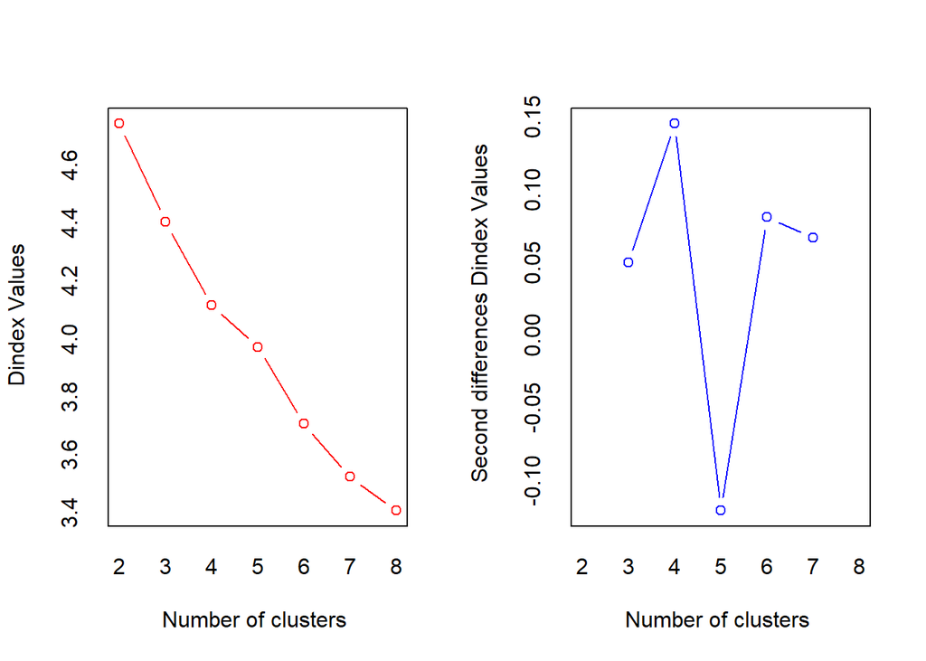

```
## *** : The D index is a graphical method of determining the number of clusters.
##                 In the plot of D index, we seek a significant knee (the significant peak in Dindex
##                 second differences plot) that corresponds to a significant increase of the value of
##                 the measure.
##
## * Among all indices:
## * 9 proposed 2 as the best number of clusters
## * 6 proposed 3 as the best number of clusters
## * 5 proposed 4 as the best number of clusters
## * 2 proposed 7 as the best number of clusters
## * 2 proposed 8 as the best number of clusters
##
##                    ***** Conclusion *****
##
## * According to the majority rule, the best number of clusters is  2
##
##
```

```r
####### Method 2: K-means on B-spline COefficients
err1.fd.coefs = t(err1.fd$coefs)
# Select number of cluster
set.seed(8888)
bsp.kmeans.num <- NbClust(err1.fd.coefs, distance = "euclidean",
                          min.nc=2, max.nc=8,
                          method = "kmeans",
                          index = "all")
```

```r
max(bsp.kmeans.num$Best.partition) ## suggest 2
```

```
## [1] 2
```

```r
####### Method 3: FunFEM Clustering Using BIC Criterions
set.seed(8888)
fem.bic = funFEM(err1.fd,K = 2:8,model = "all", crit = "bic", init = "kmeans",eps = 1e-5)
```

[output not shown]

```r
fem.bic$K ##Suggest 4
```

```
## [1] 4
```

```r
####### Method 4: FunFEM Clustering Using ICL Criterions
set.seed(8888)
fem.icl = funFEM(err1.fd,K = 2:8,model = "all", crit = "icl", init = "kmeans",eps = 1e-5)
```

[output not shown]

```r
fem.icl$K ##Suggest 4
```

```
## [1] 4
```

```r
### According to the Simulation Study, FunFEM has outstanding performance compared to K-means on Cluster Number Selection
### So we believe the Cluster Number Selection Result in FunFEM, and choose cluster number K = 4



############### Clustering Goal 2: Final Clustering Result with Cluster Number = 4
####### Method 1: K-means on Smoothed FPC Scores
# Tuning Start Point: 8,88,888,8888,88888,888888,8888888,88888888
sd.fpc.clu4  <- matrix(NA, nrow=8, ncol=2)
rr=1
seed.candidate = c(8,88,888,8888,88888,888888,8888888,88888888)
sd.fpc.clu4[,1] = seed.candidate
for (rr in 1:8){
  set.seed(seed.candidate[rr])

  fpca.smooth.temp = fpca.smooth
  fpc4.temp <- kmeans(fpca.score , 4) # 4 cluster solution
  fpca.smooth.temp$fpca4 <- fpc4.temp$cluster

  ## 4 clusters
  # 1
  kfpc4.state.1.temp = fpca.smooth.temp[fpca.smooth.temp$fpca4 == 1,]$state
  kfpc4.state.1.ts.temp = matrix(unlist(mindiff.state.1[,names(mindiff.state.1)%in%kfpc4.state.1.temp]),ncol= table(fpca.smooth.temp$fpca4)[1])
  kfpc4.state.1.fd.temp = smooth.basis(argvals = mindiff.date.1, y = kfpc4.state.1.ts.temp, err1.basis)$fd

  # 2
  kfpc4.state.2.temp = fpca.smooth.temp[fpca.smooth.temp$fpca4 == 2,]$state
  kfpc4.state.2.ts.temp = matrix(unlist(mindiff.state.1[,names(mindiff.state.1)%in%kfpc4.state.2.temp]),ncol= table(fpca.smooth.temp$fpca4)[2])
  kfpc4.state.2.fd.temp = smooth.basis(argvals = mindiff.date.1, y = kfpc4.state.2.ts.temp, err1.basis)$fd

  # 3
  kfpc4.state.3.temp = fpca.smooth.temp[fpca.smooth.temp$fpca4 == 3,]$state
  kfpc4.state.3.ts.temp = matrix(unlist(mindiff.state.1[,names(mindiff.state.1)%in%kfpc4.state.3.temp]),ncol= table(fpca.smooth.temp$fpca4)[3])
  kfpc4.state.3.fd.temp = smooth.basis(argvals = mindiff.date.1, y = kfpc4.state.3.ts.temp, err1.basis)$fd

  # 4
  kfpc4.state.4.temp = fpca.smooth.temp[fpca.smooth.temp$fpca4 == 4,]$state
  kfpc4.state.4.ts.temp = matrix(unlist(mindiff.state.1[,names(mindiff.state.1)%in%kfpc4.state.4.temp]),ncol= table(fpca.smooth.temp$fpca4)[4])
  kfpc4.state.4.fd.temp = smooth.basis(argvals = mindiff.date.1, y = kfpc4.state.4.ts.temp, err1.basis)$fd

  sd.all.temp = c(int.simpson(sd.fd(kfpc4.state.1.fd.temp),method="TRAPZ"),
                  int.simpson(sd.fd(kfpc4.state.2.fd.temp),method="TRAPZ"),
                  int.simpson(sd.fd(kfpc4.state.3.fd.temp),method="TRAPZ"),
                  int.simpson(sd.fd(kfpc4.state.4.fd.temp),method="TRAPZ"))
  sd.fpc.clu4[rr,2] <- mean(sd.all.temp)
}

best.fpc.seed<- sd.fpc.clu4[which.min(sd.fpc.clu4[,2]),1]
set.seed(best.fpc.seed)
kmeans.fpca.4 <- kmeans(fpca.score, 4) # Final 4 cluster solution
# Final clustering Result
fpca.smooth <- data.frame(fpca.smooth, fpc.4.large = kmeans.fpca.4$cluster)

####### Method 2: K-means on B-spline Coefficients with Tuning Start Point 8,88,888,8888,88888,888888,8888888,88888888
sd.bsp.clu4 <- matrix(NA, nrow=8, ncol=2)
rr=1
seed.candidate = c(8,88,888,8888,88888,888888,8888888,88888888)
sd.bsp.clu4[,1] = seed.candidate
for (rr in 1:8){
  set.seed(seed.candidate[rr])

  fpca.ts.1.temp = fpca.smooth
  fpca.temp <- kmeans(err1.fd.coefs, 4) # 4 cluster solution
  fpca.ts.1.temp$bsp4 <- fpca.temp$cluster

  ## 4 clusters
  # 1
  kfpc4.state.1.temp = fpca.ts.1.temp[fpca.ts.1.temp$bsp4 == 1,]$state
  kfpc4.state.1.ts.temp = matrix(unlist(mindiff.state.1[,names(mindiff.state.1)%in%kfpc4.state.1.temp]),ncol= table(fpca.ts.1.temp$bsp4)[1])
  kfpc4.state.1.fd.temp = smooth.basis(argvals = mindiff.date.1, y = kfpc4.state.1.ts.temp, err1.basis)$fd

  # 2
  kfpc4.state.2.temp = fpca.ts.1.temp[fpca.ts.1.temp$bsp4 == 2,]$state
  kfpc4.state.2.ts.temp = matrix(unlist(mindiff.state.1[,names(mindiff.state.1)%in%kfpc4.state.2.temp]),ncol= table(fpca.ts.1.temp$bsp4)[2])
  kfpc4.state.2.fd.temp = smooth.basis(argvals = mindiff.date.1, y = kfpc4.state.2.ts.temp, err1.basis)$fd

  # 3
  kfpc4.state.3.temp = fpca.ts.1.temp[fpca.ts.1.temp$bsp4 == 3,]$state
  kfpc4.state.3.ts.temp = matrix(unlist(mindiff.state.1[,names(mindiff.state.1)%in%kfpc4.state.3.temp]),ncol= table(fpca.ts.1.temp$bsp4)[3])
  kfpc4.state.3.fd.temp = smooth.basis(argvals = mindiff.date.1, y = kfpc4.state.3.ts.temp, err1.basis)$fd

  # 4
  kfpc4.state.4.temp = fpca.ts.1.temp[fpca.ts.1.temp$bsp4 == 4,]$state
  kfpc4.state.4.ts.temp = matrix(unlist(mindiff.state.1[,names(mindiff.state.1)%in%kfpc4.state.4.temp]),ncol= table(fpca.ts.1.temp$bsp4)[4])
  kfpc4.state.4.fd.temp = smooth.basis(argvals = mindiff.date.1, y = kfpc4.state.4.ts.temp, err1.basis)$fd

  sd.all.temp = c(int.simpson(sd.fd(kfpc4.state.1.fd.temp),method="TRAPZ"),
                  int.simpson(sd.fd(kfpc4.state.2.fd.temp),method="TRAPZ"),
                  int.simpson(sd.fd(kfpc4.state.3.fd.temp),method="TRAPZ"),
                  int.simpson(sd.fd(kfpc4.state.4.fd.temp),method="TRAPZ"))
  sd.bsp.clu4[rr,2] <- mean(sd.all.temp)
}

best.bsp.seed<- sd.bsp.clu4[which.min(sd.bsp.clu4[,2]),1]
set.seed(best.bsp.seed)
kmeans.bsp.4 <- kmeans(err1.fd.coefs, 4) # Final 4 cluster solution
# Final clustering Result
fpca.smooth <- data.frame(fpca.smooth, bsp.4 = kmeans.bsp.4$cluster)

####### Method 3: FunFEM Clustering Using BIC Criterions with Tuning Start Point 8,88,888,8888,88888,888888,8888888,88888888
sd.fem.clu4 <- matrix(NA, nrow=8, ncol=2)
rr=1
seed.candidate = c(8,88,888,8888,88888,888888,8888888,88888888)
sd.fem.clu4[,1] = seed.candidate
for (rr in 1:8){
  set.seed(seed.candidate[rr])

  fpca.ts.1.temp = fpca.smooth
  fpca.temp <- funFEM(err1.fd,K = 4,model = "all",crit = "bic", init = "kmeans",eps = 1e-5) # 4 cluster solution
  fpca.ts.1.temp$fem4 <- fpca.temp$cls

  ## 4 clusters
  # 1
  kfpc4.state.1.temp = fpca.ts.1.temp[fpca.ts.1.temp$fem4 == 1,]$state
  kfpc4.state.1.ts.temp = matrix(unlist(mindiff.state.1[,names(mindiff.state.1)%in%kfpc4.state.1.temp]),ncol= table(fpca.ts.1.temp$fem4)[1])
  kfpc4.state.1.fd.temp = smooth.basis(argvals = mindiff.date.1, y = kfpc4.state.1.ts.temp, err1.basis)$fd

  # 2
  kfpc4.state.2.temp = fpca.ts.1.temp[fpca.ts.1.temp$fem4 == 2,]$state
  kfpc4.state.2.ts.temp = matrix(unlist(mindiff.state.1[,names(mindiff.state.1)%in%kfpc4.state.2.temp]),ncol= table(fpca.ts.1.temp$fem4)[2])
  kfpc4.state.2.fd.temp = smooth.basis(argvals = mindiff.date.1, y = kfpc4.state.2.ts.temp, err1.basis)$fd

  # 3
  kfpc4.state.3.temp = fpca.ts.1.temp[fpca.ts.1.temp$fem4 == 3,]$state
  kfpc4.state.3.ts.temp = matrix(unlist(mindiff.state.1[,names(mindiff.state.1)%in%kfpc4.state.3.temp]),ncol= table(fpca.ts.1.temp$fem4)[3])
  kfpc4.state.3.fd.temp = smooth.basis(argvals = mindiff.date.1, y = kfpc4.state.3.ts.temp, err1.basis)$fd

  # 4
  kfpc4.state.4.temp = fpca.ts.1.temp[fpca.ts.1.temp$fem4 == 4,]$state
  kfpc4.state.4.ts.temp = matrix(unlist(mindiff.state.1[,names(mindiff.state.1)%in%kfpc4.state.4.temp]),ncol= table(fpca.ts.1.temp$fem4)[4])
  kfpc4.state.4.fd.temp = smooth.basis(argvals = mindiff.date.1, y = kfpc4.state.4.ts.temp, err1.basis)$fd

  sd.all.temp = c(int.simpson(sd.fd(kfpc4.state.1.fd.temp),method="TRAPZ"),
                  int.simpson(sd.fd(kfpc4.state.2.fd.temp),method="TRAPZ"),
                  int.simpson(sd.fd(kfpc4.state.3.fd.temp),method="TRAPZ"),
                  int.simpson(sd.fd(kfpc4.state.4.fd.temp),method="TRAPZ"))
  sd.fem.clu4[rr,2] <- mean(sd.all.temp)
}

best.fem.seed<- sd.fem.clu4[which.min(sd.fem.clu4[,2]),1]
set.seed(best.fem.seed)
kmeans.fem.4 <- funFEM(err1.fd,K = 4,model = "all",crit = "bic", init = "kmeans",eps = 1e-5) # Final 4 cluster solution
# 4 cluster solution
fpca.smooth <- data.frame(fpca.smooth, fem.4 = kmeans.fem.4$cls)

####### Method 4: FunFEM Clustering Using ICL Criterions with Tuning Start Point 8,88,888,8888,88888,888888,8888888,88888888
sd.fem.clu4 <- matrix(NA, nrow=8, ncol=2)
rr=1
seed.candidate = c(8,88,888,8888,88888,888888,8888888,88888888)
sd.fem.clu4[,1] = seed.candidate
for (rr in 1:8){
  set.seed(seed.candidate[rr])

  fpca.ts.1.temp = fpca.smooth
  fpca.temp <- funFEM(err1.fd,K = 4,model = "all",crit = "icl", init = "kmeans",eps = 1e-5) # 4 cluster solution
  fpca.ts.1.temp$fem4 <- fpca.temp$cls

  ## 4 clusters
  # 1
  kfpc4.state.1.temp = fpca.ts.1.temp[fpca.ts.1.temp$fem4 == 1,]$state
  kfpc4.state.1.ts.temp = matrix(unlist(mindiff.state.1[,names(mindiff.state.1)%in%kfpc4.state.1.temp]),ncol= table(fpca.ts.1.temp$fem4)[1])
  kfpc4.state.1.fd.temp = smooth.basis(argvals = mindiff.date.1, y = kfpc4.state.1.ts.temp, err1.basis)$fd

  # 2
  kfpc4.state.2.temp = fpca.ts.1.temp[fpca.ts.1.temp$fem4 == 2,]$state
  kfpc4.state.2.ts.temp = matrix(unlist(mindiff.state.1[,names(mindiff.state.1)%in%kfpc4.state.2.temp]),ncol= table(fpca.ts.1.temp$fem4)[2])
  kfpc4.state.2.fd.temp = smooth.basis(argvals = mindiff.date.1, y = kfpc4.state.2.ts.temp, err1.basis)$fd

  # 3
  kfpc4.state.3.temp = fpca.ts.1.temp[fpca.ts.1.temp$fem4 == 3,]$state
  kfpc4.state.3.ts.temp = matrix(unlist(mindiff.state.1[,names(mindiff.state.1)%in%kfpc4.state.3.temp]),ncol= table(fpca.ts.1.temp$fem4)[3])
  kfpc4.state.3.fd.temp = smooth.basis(argvals = mindiff.date.1, y = kfpc4.state.3.ts.temp, err1.basis)$fd

  # 4
  kfpc4.state.4.temp = fpca.ts.1.temp[fpca.ts.1.temp$fem4 == 4,]$state
  kfpc4.state.4.ts.temp = matrix(unlist(mindiff.state.1[,names(mindiff.state.1)%in%kfpc4.state.4.temp]),ncol= table(fpca.ts.1.temp$fem4)[4])
  kfpc4.state.4.fd.temp = smooth.basis(argvals = mindiff.date.1, y = kfpc4.state.4.ts.temp, err1.basis)$fd

  sd.all.temp = c(int.simpson(sd.fd(kfpc4.state.1.fd.temp),method="TRAPZ"),
                  int.simpson(sd.fd(kfpc4.state.2.fd.temp),method="TRAPZ"),
                  int.simpson(sd.fd(kfpc4.state.3.fd.temp),method="TRAPZ"),
                  int.simpson(sd.fd(kfpc4.state.4.fd.temp),method="TRAPZ"))
  sd.fem.clu4[rr,2] <- mean(sd.all.temp)
}

best.fem.seed<- sd.fem.clu4[which.min(sd.fem.clu4[,2]),1]
set.seed(best.fem.seed)
kmeans.fem.4 <- funFEM(err1.fd,K = 4,model = "all",crit = "icl", init = "kmeans",eps = 1e-5) # Final 4 cluster solution
# Final clustering Result
fpca.smooth <- data.frame(fpca.smooth, fem.4.icl = kmeans.fem.4$cls)


####### Matching the Cluster Results Among 4 Clustering Methods Using Hungarian Algorithm For Cluster Mapping
# labels from cluster A will be matched on the labels from cluster B
minWeightBipartiteMatching <- function(clusteringA, clusteringB) {
  require(clue)
  idsA <- unique(clusteringA)  # distinct cluster ids in a
  idsB <- unique(clusteringB)  # distinct cluster ids in b
  nA <- length(clusteringA)  # number of instances in a
  nB <- length(clusteringB)  # number of instances in b
  if (length(idsA) != length(idsB) || nA != nB) {
    stop("number of cluster or number of instances do not match")
  }

  nC <- length(idsA)
  tupel <- c(1:nA)

  # computing the distance matrix
  assignmentMatrix <- matrix(rep(-1, nC * nC), nrow = nC)
  for (i in 1:nC) {
    tupelClusterI <- tupel[clusteringA == i]
    solRowI <- sapply(1:nC, function(i, clusterIDsB, tupelA_I) {
      nA_I <- length(tupelA_I)  # number of elements in cluster I
      tupelB_I <- tupel[clusterIDsB == i]
      nB_I <- length(tupelB_I)
      nTupelIntersect <- length(intersect(tupelA_I, tupelB_I))
      return((nA_I - nTupelIntersect) + (nB_I - nTupelIntersect))
    }, clusteringB, tupelClusterI)
    assignmentMatrix[i, ] <- solRowI
  }

  # optimization
  result <- solve_LSAP(assignmentMatrix, maximum = FALSE)
  attr(result, "assignmentMatrix") <- assignmentMatrix
  return(result)
}

## changing the labels following the matching result!
minWeightBipartiteMatching(fpca.smooth$bsp.4,fpca.smooth$fpc.4.large) # 1 => 4, 2 => 3, 3 => 2, 4 => 1
```

```
## Optimal assignment:
## 1 => 4, 2 => 3, 3 => 2, 4 => 1
```

```r
fpca.smooth$fpc.4.large.rep = fpca.smooth$fpc.4.large
fpca.smooth$fpc.4.large[fpca.smooth$fpc.4.large.rep==4]=1
fpca.smooth$fpc.4.large[fpca.smooth$fpc.4.large.rep==3]=2
fpca.smooth$fpc.4.large[fpca.smooth$fpc.4.large.rep==2]=3
fpca.smooth$fpc.4.large[fpca.smooth$fpc.4.large.rep==1]=4
minWeightBipartiteMatching(fpca.smooth$bsp.4,fpca.smooth$fem.4) # 1 => 2, 2 => 3, 3 => 4, 4 => 1
```

```
## Optimal assignment:
## 1 => 2, 2 => 3, 3 => 4, 4 => 1
```

```r
fpca.smooth$fem.4.rep = fpca.smooth$fem.4
fpca.smooth$fem.4[fpca.smooth$fem.4.rep==2]=1
fpca.smooth$fem.4[fpca.smooth$fem.4.rep==3]=2
fpca.smooth$fem.4[fpca.smooth$fem.4.rep==4]=3
fpca.smooth$fem.4[fpca.smooth$fem.4.rep==1]=4
minWeightBipartiteMatching(fpca.smooth$bsp.4,fpca.smooth$fem.4.icl) # 1 => 2, 2 => 3, 3 => 4, 4 => 1
```

```
## Optimal assignment:
## 1 => 2, 2 => 3, 3 => 4, 4 => 1
```

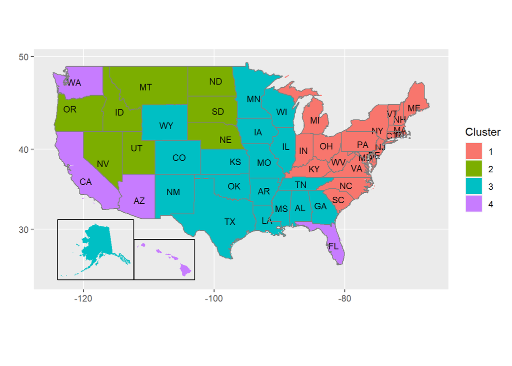

```r
fpca.smooth$fem.4.icl.rep = fpca.smooth$fem.4.icl
fpca.smooth$fem.4.icl[fpca.smooth$fem.4.icl.rep==2]=1
fpca.smooth$fem.4.icl[fpca.smooth$fem.4.icl.rep==3]=2
fpca.smooth$fem.4.icl[fpca.smooth$fem.4.icl.rep==4]=3
fpca.smooth$fem.4.icl[fpca.smooth$fem.4.icl.rep==1]=4


######## Figure 5: Map Visualization on Clustering Result
region <- read.csv("region-to-state.new.csv",header = T, stringsAsFactors = F)
region$state = tolower(region$state)
region_noremoted = region[!(region$state %in% c("alaska","hawaii")),]

# K-means Clustering on Smoothed FPC Scores with Start Point Tuning
fpca.smooth$state = tolower(fpca.smooth$state)
fpc4.smooth.tuned.large = ggplot(fpca.smooth, aes(map_id = state)) +
  geom_map(aes(fill = factor(fpc.4.large)),map = fifty_states) +
  expand_limits(x = fifty_states$long, y = fifty_states$lat) +
  coord_map()  +
  labs(x = "",y = "",  fill = "Cluster")+
  geom_text(data = region_noremoted, aes(long,lag,label = state.short), size=3)+
  fifty_states_inset_boxes()+ borders("state")
# If there is an error when visualizing the plot, please run
#dev.off()
######## Figure 5 (b)
fpc4.smooth.tuned.large
```

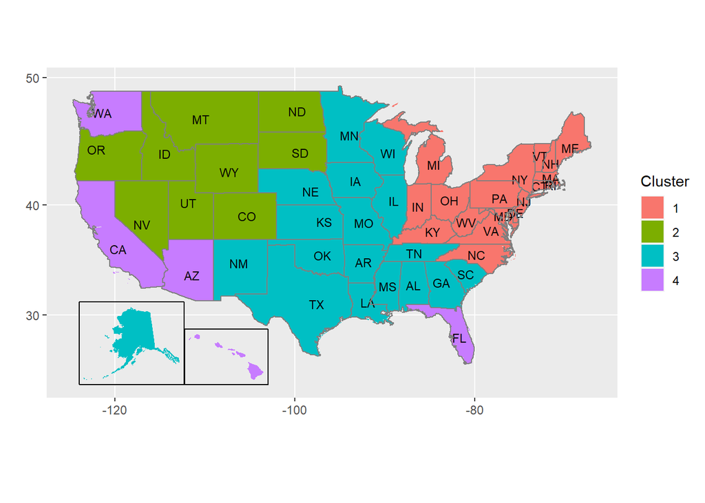

```r
# B-spline Coefficients with Start Point Tuning
fpca.smooth$state = tolower(fpca.smooth$state)
bsp4.tuned = ggplot(fpca.smooth, aes(map_id = state)) +
  geom_map(aes(fill = factor(bsp.4)),map = fifty_states) +
  expand_limits(x = fifty_states$long, y = fifty_states$lat) +
  coord_map()  +
  labs(x = "",y = "",  fill = "Cluster")+
  geom_text(data = region_noremoted, aes(long,lag,label = state.short), size=3)+
  fifty_states_inset_boxes()+ borders("state")
# If there is an error when visualizing the plot, please run
#dev.off()
######## Figure 5 (a)
bsp4.tuned
```

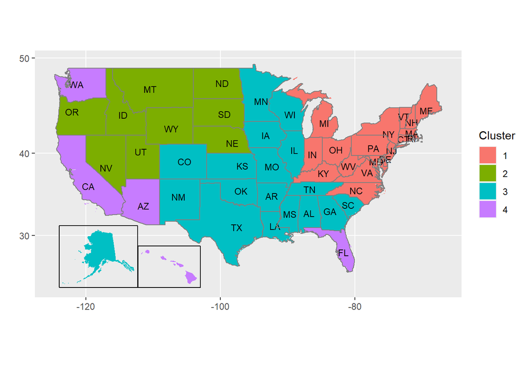

```r
# FunFEM BIC
fpca.smooth$state = tolower(fpca.smooth$state)
fem4.tuned = ggplot(fpca.smooth, aes(map_id = state)) +
  geom_map(aes(fill = factor(fem.4)),map = fifty_states) +
  expand_limits(x = fifty_states$long, y = fifty_states$lat) +
  coord_map()  +
  labs(x = "",y = "",  fill = "Cluster")+
  geom_text(data = region_noremoted, aes(long,lag,label = state.short), size=3)+
  fifty_states_inset_boxes()+ borders("state")
# If there is an error when visualizing the plot, please run
#dev.off()
######## Figure 5 (c)
fem4.tuned
```

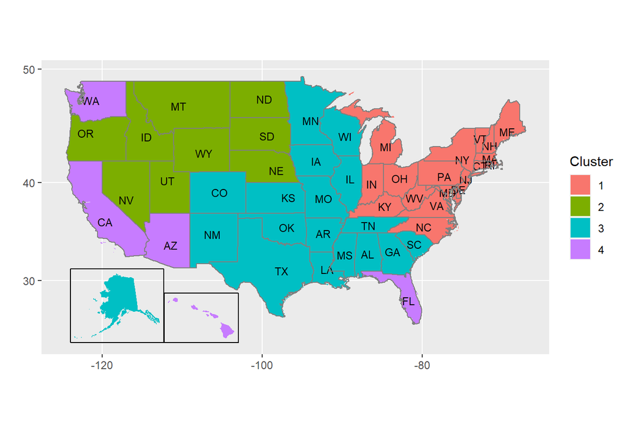

```r
# FunFEM ICL
fpca.smooth$state = tolower(fpca.smooth$state)
fem4.tuned.icl = ggplot(fpca.smooth, aes(map_id = state)) +
  geom_map(aes(fill = factor(fem.4.icl)),map = fifty_states) +
  expand_limits(x = fifty_states$long, y = fifty_states$lat) +
  coord_map()  +
  labs(x = "",y = "",  fill = "Cluster")+
  geom_text(data = region_noremoted, aes(long,lag,label = state.short), size=3)+
  fifty_states_inset_boxes()+ borders("state")
# If there is an error when visualizing the plot, please run
#dev.off()
######## Figure 5 (c)
fem4.tuned.icl
```

#### 6. Error Cureve Over-time Visualization by Cluster (fig 6 and table 1)

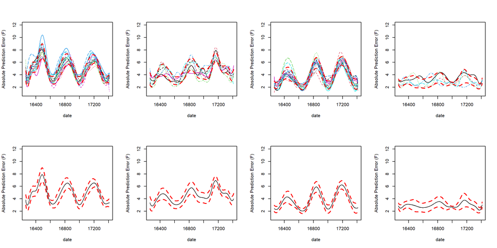

| mu.clu1 | mu.clu2 | mu.clu3 | mu.clu4 |
| --- | --- | --- | --- |
| 5.184651 | 4.710836 | 3.948358 | 3.108288 |

```r
######## Curves Visualization in each Cluster with 95% Confidence Interval
plot.ci = function(result.df, original.ts, method){
  temp.df = result.df
  if (method == "fpc.large"){
    temp.df$temp.clu = temp.df$fpc.4.large
  }else if (method == "bsp"){
    temp.df$temp.clu = temp.df$bsp.4
  }else if (method == "fem"){
    temp.df$temp.clu = temp.df$fem.4
  }else{
    temp.df$temp.clu = temp.df$fem.4.icl
  }

  par(mfcol=c(2,4))

  ## 4 clusters
  temp.state.1 = temp.df[temp.df$temp.clu == 1,]$state
  temp.state.1.ts = matrix(unlist(original.ts[,names(original.ts)%in%temp.state.1]),ncol= table(temp.df$temp.clu)[1])
  temp.state.1.fd = smooth.basis(argvals = mindiff.date.1, y = temp.state.1.ts, err1.basis)$fd

  temp.state.2 = temp.df[temp.df$temp.clu == 2,]$state
  temp.state.2.ts = matrix(unlist(original.ts[,names(original.ts)%in%temp.state.2]),ncol= table(temp.df$temp.clu)[2])
  temp.state.2.fd = smooth.basis(argvals = mindiff.date.1, y = temp.state.2.ts, err1.basis)$fd

  temp.state.3 = temp.df[temp.df$temp.clu == 3,]$state
  temp.state.3.ts = matrix(unlist(original.ts[,names(original.ts)%in%temp.state.3]),ncol= table(temp.df$temp.clu)[3])
  temp.state.3.fd = smooth.basis(argvals = mindiff.date.1, y = temp.state.3.ts, err1.basis)$fd


  temp.state.4 = temp.df[temp.df$temp.clu == 4,]$state
  temp.state.4.ts = matrix(unlist(original.ts[,names(original.ts)%in%temp.state.4]),ncol= table(temp.df$temp.clu)[4])
  temp.state.4.fd = smooth.basis(argvals = mindiff.date.1, y = temp.state.4.ts, err1.basis)$fd

  # 95% CI
  muhat = mean.fd(temp.state.1.fd)
  sdhat = sd.fd(temp.state.1.fd)
  n = length(temp.state.1.fd)
  se_hat_u = fd(basisobj = err1.basis)
  se_hat_u$coefs = 1.96*sdhat$coefs/sqrt(n) + muhat$coefs
  se_hat_l = fd(basisobj = err1.basis)
  se_hat_l$coefs = -1.96*sdhat$coefs/sqrt(n) + muhat$coefs

  plot(temp.state.1.fd,ylim = c(1,12),ylab = "Absolute Prediction Error (F)", xlab = "date",cex.lab=1.65,cex.axis=1.4)
  lines(se_hat_l,col = "red",lty = 2, lwd = 2)
  lines(se_hat_u,col = "red",lty = 2, lwd = 2)

  plot(muhat,ylim = c(1,12),ylab = "Absolute Prediction Error (F)", xlab = "date",cex.lab=1.65,cex.axis=1.4)
  lines(se_hat_l,col = "red",lty = 2, lwd = 2)
  lines(se_hat_u,col = "red",lty = 2, lwd = 2)

  muhat = mean.fd(temp.state.2.fd)
  sdhat = sd.fd(temp.state.2.fd)
  n = length(temp.state.2.fd)
  se_hat_u = fd(basisobj = err1.basis)
  se_hat_u$coefs = 1.96*sdhat$coefs/sqrt(n) + muhat$coefs
  se_hat_l = fd(basisobj = err1.basis)
  se_hat_l$coefs = -1.96*sdhat$coefs/sqrt(n) + muhat$coefs

  plot(temp.state.2.fd,ylim = c(1,12),ylab = "Absolute Prediction Error (F)", xlab = "date",cex.lab=1.65,cex.axis=1.4)
  lines(se_hat_l,col = "red",lty = 2, lwd = 2)
  lines(se_hat_u,col = "red",lty = 2, lwd = 2)

  plot(muhat,ylim = c(1,12),ylab = "Absolute Prediction Error (F)", xlab = "date",cex.lab=1.65,cex.axis=1.4)
  lines(se_hat_l,col = "red",lty = 2, lwd = 2)
  lines(se_hat_u,col = "red",lty = 2, lwd = 2)

  muhat = mean.fd(temp.state.3.fd)
  sdhat = sd.fd(temp.state.3.fd)
  n = length(temp.state.3.fd)
  se_hat_u = fd(basisobj = err1.basis)
  se_hat_u$coefs = 1.96*sdhat$coefs/sqrt(n) + muhat$coefs
  se_hat_l = fd(basisobj = err1.basis)
  se_hat_l$coefs = -1.96*sdhat$coefs/sqrt(n) + muhat$coefs

  plot(temp.state.3.fd,ylim = c(1,12),ylab = "Absolute Prediction Error (F)", xlab = "date",cex.lab=1.65,cex.axis=1.4)
  lines(se_hat_l,col = "red",lty = 2, lwd = 2)
  lines(se_hat_u,col = "red",lty = 2, lwd = 2)

  plot(muhat, ylim = c(1,12),ylab = "Absolute Prediction Error (F)", xlab = "date",cex.lab=1.65,cex.axis=1.4)
  lines(se_hat_l,col = "red",lty = 2, lwd = 2)
  lines(se_hat_u,col = "red",lty = 2, lwd = 2)

  muhat = mean.fd(temp.state.4.fd)
  sdhat = sd.fd(temp.state.4.fd)
  n = length(temp.state.4.fd)
  se_hat_u = fd(basisobj = err1.basis)
  se_hat_u$coefs = 1.96*sdhat$coefs/sqrt(n) + muhat$coefs
  se_hat_l = fd(basisobj = err1.basis)
  se_hat_l$coefs = -1.96*sdhat$coefs/sqrt(n) + muhat$coefs

  plot(temp.state.4.fd,ylim = c(1,12),ylab = "Absolute Prediction Error (F)", xlab = "date",cex.lab=1.65,cex.axis=1.4)
  lines(se_hat_l,col = "red",lty = 2, lwd = 2)
  lines(se_hat_u,col = "red",lty = 2, lwd = 2)

  plot(muhat, ylim = c(1,12),ylab = "Absolute Prediction Error (F)", xlab = "date",cex.lab=1.65,cex.axis=1.4)
  lines(se_hat_l,col = "red",lty = 2, lwd = 2)
  lines(se_hat_u,col = "red",lty = 2, lwd = 2)

  sd.all = c(int.simpson(sd.fd(temp.state.1.fd),method="TRAPZ"),
             int.simpson(sd.fd(temp.state.2.fd), method="TRAPZ"),
             int.simpson(sd.fd(temp.state.3.fd), method="TRAPZ"),
             int.simpson(sd.fd(temp.state.4.fd), method="TRAPZ"))

  rank.df = data.frame(#sd.mu = mean(sd.all),
                       mu.clu1 = int.simpson(mean.fd(temp.state.1.fd), method="TRAPZ")/(365*3),
                       mu.clu2 = int.simpson(mean.fd(temp.state.2.fd), method="TRAPZ")/(365*3),
                       mu.clu3 = int.simpson(mean.fd(temp.state.3.fd), method="TRAPZ")/(365*3),
                       mu.clu4 = int.simpson(mean.fd(temp.state.4.fd), method="TRAPZ")/(365*3))

  return(rank.df)
}

######## Figure 6 and Table 1: The 4 plots at the top line are the plots in figure 6
#plot.ci(fpca.smooth, mindiff.state.1, "fpc.large")
#plot.ci(fpca.smooth, mindiff.state.1, "bsp")
plot.ci(fpca.smooth, mindiff.state.1, "fem")
```

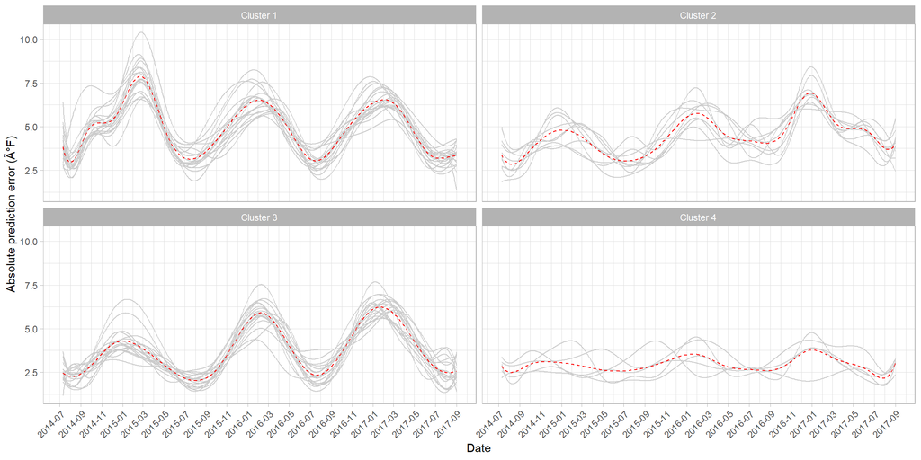

```r
#plot.ci(fpca.smooth, mindiff.state.1, "fem.icl")

write.csv(fpca.smooth, file = 'real_analysis_result.csv',row.names = F)

### Figure 6 ###
real_analysis_result <- read_csv("real_analysis_result.csv")

curve_plot_df = smooth_curve_df %>%
  pivot_longer(
    cols = alabama:wyoming,
    names_to = "state",
    values_to = "temp"
  ) %>%
  left_join(real_analysis_result %>%
              dplyr::select(state, cluster = fem.4) %>%
              mutate(cluster = paste0("Cluster ", cluster)))

overall_mean_curve = smooth_curve_df %>%
  mutate(avg_temp = apply(smooth_curve_df[, 2:51], 1, mean)) %>%
  dplyr::select(date, avg_temp)

cluster_mean_curve = curve_plot_df %>%
  group_by(date, cluster) %>%
  summarise(avg_temp = mean(temp)) %>%
  ungroup()

fig_6 = curve_plot_df %>%
  ggplot() +
  geom_line(aes(x = date, y = temp, group = state), col = "gray80") +
  geom_line(data = cluster_mean_curve,
            aes(x = date, y = avg_temp), col = "red", lty = 2) +
  theme_light() +
  scale_x_date(date_breaks = "2 month", date_labels = "%Y-%m") +
  theme(axis.text.x = element_text(angle = 45, hjust = 1)) +
  facet_wrap(~cluster) +
  ylab("Absolute prediction error (Â°F)") + xlab("Date")
fig_6
```

#### 7. Visualization on Exception Curves

```r
##### Grabbing data of four exception states and making as fd.data
#NE
nebraska = mindiff.state.1[,which(names(mindiff.state.1) %in% c("nebraska"))]
ne.mat = matrix(unlist(nebraska),ncol = 1)
ne.fd = smooth.basis(argvals = mindiff.date.1, y = ne.mat, err1.basis)$fd

#WY
wyoming = mindiff.state.1[,which(names(mindiff.state.1) %in% c("wyoming"))]
wy.mat = matrix(unlist(wyoming),ncol = 1)
wy.fd = smooth.basis(argvals = mindiff.date.1, y = wy.mat, err1.basis)$fd

#CO
colorado = mindiff.state.1[,which(names(mindiff.state.1) %in% c("colorado"))]
co.mat = matrix(unlist(colorado),ncol = 1)
co.fd = smooth.basis(argvals = mindiff.date.1, y = co.mat, err1.basis)$fd

#SC
south.ca = mindiff.state.1[,which(names(mindiff.state.1) %in% c("south carolina"))]
sc.mat = matrix(unlist(south.ca),ncol = 1)
sc.fd = smooth.basis(argvals = mindiff.date.1, y = sc.mat, err1.basis)$fd

##### function of grabbing mean fd from some clusters in different method
get.mean.fd = function(result.df, original.ts, method, cluster){
  temp.df = result.df
  if (method == "fpc.large"){
    temp.df$temp.clu = temp.df$fpc.4.large
  }else if (method == "bsp"){
    temp.df$temp.clu = temp.df$bsp.4
  }else if (method == "fem"){
    temp.df$temp.clu = temp.df$fem.4
  }else{
    temp.df$temp.clu = temp.df$fem.4.icl
  }

  ## mean fd of the clusters
  temp.state.1 = temp.df[temp.df$temp.clu == cluster,]$state
  temp.state.1.ts = matrix(unlist(original.ts[,names(original.ts)%in%temp.state.1]),ncol= table(temp.df$temp.clu)[cluster])
  temp.state.1.fd = smooth.basis(argvals = mindiff.date.1, y = temp.state.1.ts, err1.basis)$fd
  return(mean.fd(temp.state.1.fd))
}

##### Figure 7 Plotting:
par(mfrow=c(2,2))
muhat.fpc.cl3 = get.mean.fd(fpca.smooth, mindiff.state.1, "fpc.large",3)
muhat.fem.cl2 = get.mean.fd(fpca.smooth, mindiff.state.1, "fem",2)
plot.fd(wy.fd, ylim = c(1,12),ylab = "Absolute Prediction Error (F)", xlab = "date",cex.lab=1.65,cex.axis=1.4, main = "Wyoming")
```

```
## [1] "done"
```

```r
lines(muhat.fpc.cl3,col = "red",lty = 2)
lines(muhat.fem.cl2,col = "blue",lty = 2)
legend("topright", legend=c("Wyoming", "Cluster 3 in K-means on FPC Scores","Cluster 2 in FunFEM"),
       col=c("black","red", "blue"), lty=c(1,2,2), cex=1.2)

muhat.bsp.cl2 = get.mean.fd(fpca.smooth, mindiff.state.1, "bsp",2)
muhat.fem.cl3 = get.mean.fd(fpca.smooth, mindiff.state.1, "fem",3)
plot.fd(co.fd, ylim = c(1,12),ylab = "Absolute Prediction Error (F)", xlab = "date",cex.lab=1.65,cex.axis=1.4, main = "Colorado")
```

```
## [1] "done"
```

```r
lines(muhat.bsp.cl2,col = "red",lty = 2)
lines(muhat.fem.cl3,col = "blue",lty = 2)
legend("topright", legend=c("Colorado", "Cluster 2 in K-means on B-spline Coeff","Cluster 3 in FunFEM"),
       col=c("black","red", "blue"), lty=c(1,2,2), cex=1.2)

muhat.bsp.cl3 = get.mean.fd(fpca.smooth, mindiff.state.1, "bsp",3)
muhat.fem.cl2 = get.mean.fd(fpca.smooth, mindiff.state.1, "fem",2)
plot.fd(ne.fd, ylim = c(1,12),ylab = "Absolute Prediction Error (F)", xlab = "date",cex.lab=1.65,cex.axis=1.4, main = "Nebraska")
```

```
## [1] "done"
```

```r
lines(muhat.bsp.cl3,col = "red",lty = 2)
lines(muhat.fem.cl2,col = "blue",lty = 2)
legend("topright", legend=c("Nebraska", "Cluster 3 in K-means on B-spline Coeff","Cluster 2 in FEM"),
       col=c("black","red", "blue"), lty=c(1,2,2), cex=1.2)

muhat.fpc.cl1 = get.mean.fd(fpca.smooth, mindiff.state.1, "fpc.large",1)
plot.fd(sc.fd, ylim = c(1,12),ylab = "Absolute Prediction Error (F)", xlab = "date",cex.lab=1.65,cex.axis=1.4, main = "South Carolina")
```

```
## [1] "done"
```

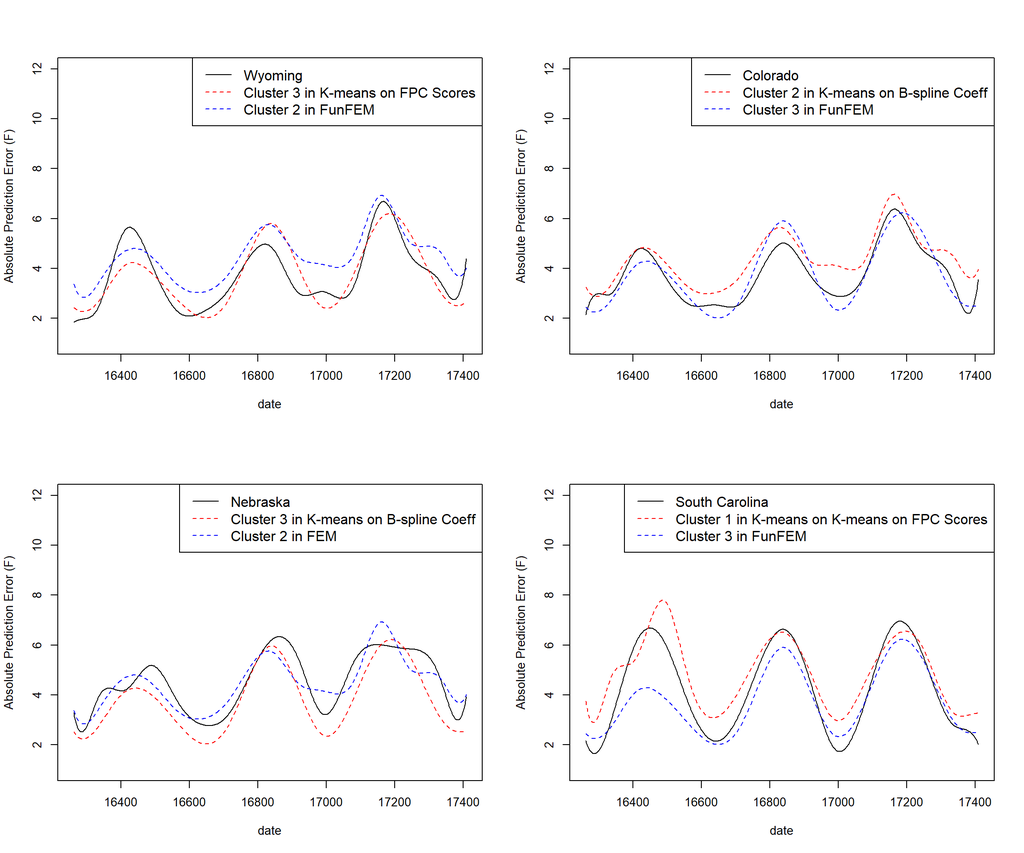

```r
lines(muhat.fpc.cl1,col = "red",lty = 2)
lines(muhat.fem.cl3,col = "blue",lty = 2)
legend("topright", legend=c("South Carolina", "Cluster 1 in K-means on K-means on FPC Scores","Cluster 3 in FunFEM"),
       col=c("black","red", "blue"), lty=c(1,2,2), cex=1.2)
```